# LLM Fine Tuning-New York Times Comments(2017)

# Model Fine Tuning

We will create a model checkpoint which is simply the chosen pre-trained Hugging Face model. Creating the model_checkpoint object makes it easier to apply the model in our process steps.

```python
model_checkpoint = "cardiffnlp/twitter-roberta-base-sentiment-latest"
```

```python
model = AutoModel.from_pretrained(model_checkpoint)
```

The device object is using the gpu if available, If the gpu is not available then the cpu will be used.

```python
device
```

```
device(type='cuda')
```

The output shows the device is ‘cuda’ meaning it is on our gpu.

```python
print("Model configuration: \n\n",model.config)
```

```
Model configuration:

 RobertaConfig {
  "architectures": [
    "RobertaForSequenceClassification"
  ],
  "attention_probs_dropout_prob": 0.1,
  "bos_token_id": 0,
  "classifier_dropout": null,
  "dtype": "float32",
  "eos_token_id": 2,
  "gradient_checkpointing": false,
  "hidden_act": "gelu",
  "hidden_dropout_prob": 0.1,
  "hidden_size": 768,
  "id2label": {
    "0": "negative",
    "1": "neutral",
    "2": "positive"
  },
  "initializer_range": 0.02,
  "intermediate_size": 3072,
  "label2id": {
    "negative": 0,
    "neutral": 1,
    "positive": 2
  },
  "layer_norm_eps": 1e-05,
  "max_position_embeddings": 514,
  "model_type": "roberta",
  "num_attention_heads": 12,
  "num_hidden_layers": 12,
  "pad_token_id": 1,
  "position_embedding_type": "absolute",
  "transformers_version": "4.57.3",
  "type_vocab_size": 1,
  "use_cache": true,
  "vocab_size": 50265
}
```

id2label

```python
print("Model id2label configuration: \n",model.config.id2label)
```

```
Model id2label configuration:
 {0: 'negative', 1: 'neutral', 2: 'positive'}
```

label2id

```python
print("Model label2id configuation: \n",model.config.label2id)
```

```
Model label2id configuation:
 {'negative': 0, 'neutral': 1, 'positive': 2}
```

From the model configuration we see the label2id and id2label variables that we needed to create for the model.

## Metrics

```python
from sklearn.metrics import accuracy_score, precision_score, recall_score, f1_score
```

```python
def compute_metrics(pred):
    """
        Calculates evaluation metrics.

        Args:
            pred: predictions from model.

        Returns:
                accuracy,precision, recall, f1 scores.

    """

    labels = pred.label_ids
    preds = pred.predictions.argmax(-1)

    acc = accuracy_score(labels, preds)
    prec = precision_score(labels, preds, average='weighted')
    rec = recall_score(labels, preds, average='weighted')
    f1 = f1_score(labels, preds, average='weighted')

    return {"accuracy": acc, "precision": prec, "recall": rec, "f1": f1}
```

The function creates the computation of our selected metrics for use during the model evaluation on our validation set.

Metric definition:

• *Accuracy* - measures the number of predictions that are correct as a percentage of the total number of predictions that are made. As an example, if 90% of your predictions are correct, your accuracy is simply 90%. Calculation: number of correct predictions/Number of total predictions. TP+TN/(TP+TN+FP+FN)

• *Precision* - tells us about the quality of positive predictions. It may not find all the positives but the ones that the model does classify as positive are likely to be correct. As an example, out of everyone predicted to have defaulted, how many of them did default? So, within everything that has been predicted as positive, precision counts the percentage that is correct. Calculation: True positives/All Positives. TP/(TP+FP)

• *Recall* - tells us about how well the model identifies true positives. The model may find a lot of positives, yet it also will incorrectly detect many positives that are not actually positives. Out of all the patients who have the disease, how many were correctly identified? So, within everything that is positive, how many did the model successfully find? A model with low recall is unable to find all (or a large part) of the positive cases in the data. Calculated as: True Positives/ (False Negatives + True Positives)

• *F1 Score* - The F1 score is defined as the harmonic mean of precision and recall. The formula for the F1 score is the following: 2 times(precision*Recall)/ (Precision + Recall)) Since the F1 score is an average of Precision and Recall, it means that the F1 score gives equal weight to Precision and Recall.

## Configure Training Arguments

```python
training_args = TrainingArguments(
    output_dir="./results",
    overwrite_output_dir=True,
    eval_strategy="epoch",
    save_strategy="epoch",
    learning_rate=2e-5,
    per_device_train_batch_size=16,
    per_device_eval_batch_size=16,
    num_train_epochs=2,
    weight_decay=0.01,
    logging_dir="./logs",
    logging_first_step=10,
    save_steps=500,
    disable_tqdm=False,
    metric_for_best_model='eval_loss',
    load_best_model_at_end=True


)
```

Training Arguments:

- *Output_dir*: the directory where we will store the results of the model.
- *overwrite_ouput_dir*: When set to true, the output directory is overwritten on a new training of the model.
- *eval_strategy*: The interval for evaluating the model. For our training we have set it to evaluate after each epoch*.
- *save_strategy*: How often to save the model. We have set it to after each epoch.
- *learning_rate*: controls how quickly the model’s parameters move towards the optimal solution (minimizing the loss function**)
- *per_device_train_batch*: subset of the entire training dataset. It is the number of samples processed before the model is updated. per_device_eval_batch_size: is the number of samples processed before the model is evaluated.
- *weight_decay*: used to discourage model from using large weight values during training. Prevents overfitting.
- *logging_dir*: directory where the logs are saved.
- *save_steps*: Determines how frequently the model’s checkpoint is saved during training.

*An epoch is the number of times that the model will work through the entire training set. This is also known as iteration. In each epoch, the training code updates the weights of the model iteration during which we update the parameters for all our training samples. Updating model weights aims to lower the risk of errors from the model predictions and improve accuracy.

## Trainer

Set up the trainer

```python
trainer = Trainer(model=model, args=training_args,
                  compute_metrics=compute_metrics,
                  train_dataset=sentiment_encoded['train'],
                  eval_dataset=sentiment_encoded['validation'],
                  processing_class=tokenizer)
```

We can now fine tune the model.

```python
trainer.train()
```

[output not shown]

Evaluation terms:

*loss function*: tells us how good or bad our model is at making predictions during training by helping us assess the differences between actual values and those predicted by the model. The lower the loss function the better our model is at making predictions.

*Generaliztion*: a model’s ability to accurately adapt to new, unseen data after being trained on a specific dataset (training set). It indicates that the model has learned underlying patterns rather than simply memorizing training data.

*Overfitting*: a model performs well on training data but poorly on evaluation or test data.

```python
print(f"Evaluation results 4 epochs and 2e-5 learning rate: \n\n {eval_results_4}")
```

```
Evaluation results 4 epochs and 2e-5 learning rate:

 {'eval_loss': 0.5481023192405701, 'eval_accuracy': 0.8808971384377416, 'eval_precision': 0.8844937293967496, 'eval_recall': 0.8808971384377416, 'eval_f1': 0.8823638838820619, 'eval_runtime': 28.9798, 'eval_samples_per_second': 133.852, 'eval_steps_per_second': 8.385, 'epoch': 4.0}
```

Our first model was trained on 38,786 rows of data, 4 epochs and a learning rate of 2e-5 (0.00002). The result was a training loss of 0.19 and and a evaluation loss of 0.54. evaluation accuracy, precision, recall, and f1 scores were all around 0.88. Though these scores are not bad the difference between training and evaluation loss is significant and indicates overfitting. We’ll train the model with different parameters on the same data.

```python
print(f"Evaluation results 3 epochs and 1e-5 learning rate: \n\n {eval_results_3}")
```

```
Evaluation results 3 epochs and 1e-5 learning rate:

 {'eval_loss': 0.40284857153892517, 'eval_accuracy': 0.8564062902810002, 'eval_precision': 0.8543414917394259, 'eval_recall': 0.8564062902810002, 'eval_f1': 0.8505442745726558, 'eval_runtime': 29.1422, 'eval_samples_per_second': 133.106, 'eval_steps_per_second': 8.338, 'epoch': 3.0}
```

This time we changed the number of epochs to 3 and reduced the learning rate to 1e-5 (0.00001). The result was a training loss loss of 0.325 and an evaluation loss of 0.40. Though the evaluation loss was lower, the training loss significantly increased. We would like to have loss scores below 0.2. Additionally, accuracy, precision, recall, and f1 scores dropped to around 0.85. Lowering the learning rate did not have a positive affect on the model. The issue could be our training data is too small, causing it to overfit on training data.

```python
print(f"Evaluation results 11% data sample: \n\n {eval_results_medium}")
```

```
Evaluation results 11% data sample:

 {'eval_loss': 0.23832528293132782, 'eval_accuracy': 0.9293147089153464, 'eval_precision': 0.9288175530957687, 'eval_recall': 0.9293147089153464, 'eval_f1': 0.9290421465269839, 'eval_runtime': 81.6927, 'eval_samples_per_second': 130.575, 'eval_steps_per_second': 8.165, 'epoch': 3.0}
```

```python
eval_results_large = trainer.evaluate()
```

```python
print(f"Evaluation results 25% data and 2 epochs:\n\n {eval_results_large}")
```

```
Evaluation results 25% data and 2 epochs:

 {'eval_loss': 0.17565062642097473, 'eval_accuracy': 0.9493441135219867, 'eval_precision': 0.9488204538818611, 'eval_recall': 0.9493441135219867, 'eval_f1': 0.9490065760895063, 'eval_runtime': 183.3649, 'eval_samples_per_second': 132.206, 'eval_steps_per_second': 8.268, 'epoch': 2.0}
```

For this round of training we increased the sample to 25% of the data, with 169,688 rows assigned to the training data. The result was a training loss 0.1531 and an evaluation loss of 0.1756. Evaluation accuracy, precision, recall, and f1 scores all improved to around 0.95. Increasing the training data to 169,688 rows provided good results as there is only a 0.022 difference between training and evaluation loss indicating minimal over fitting. We achieved our evaluation results on only 2 epochs, though even with one less epoch there was a notable increase in evaluation run eval runtime.

## Test Set Metrtics

```python
preds_output = trainer.predict(sentiment_encoded['test'])
```

```python
print("Test set metrics: \n\n",preds_output.metrics)
```

```
Test set metrics:

 {'test_loss': 0.17256054282188416, 'test_accuracy': 0.9474237861474362, 'test_precision': 0.9468511219590955, 'test_recall': 0.9474237861474362, 'test_f1': 0.947044515858654, 'test_runtime': 371.7324, 'test_samples_per_second': 130.422, 'test_steps_per_second': 8.154}
```

Predicting on the test set we see that the loss was slightly lower at 0.1725. The other metrics are similar to the evaluation results at around 0.95. This means our model is generalizing well to unseen data.

### Classification Report

In order to create our classification report and confusion matrix we will need to create predicted and actual objects. y_pred is the predictions from our fine-tuned model. You will notice that it is being created from the preds_output object. y_true are the actual outcomes from our original data. You will notice that we are creating the object from the labels of the test set.

```python
y_pred = np.argmax(preds_output.predictions, axis = 1)

y_true = sentiment_encoded['test'][:]['label']
```

```python
from sklearn.metrics import classification_report
```

```python
test_classification_rpt = classification_report(y_true, y_pred)
```

```python
print("Test set classification report: \n\n",test_classification_rpt)
```

```
Test set classification report:

               precision    recall  f1-score   support

           0       0.96      0.97      0.96     20839
           1       0.87      0.83      0.85      7260
           2       0.96      0.96      0.96     20383

    accuracy                           0.95     48482
   macro avg       0.93      0.92      0.93     48482
weighted avg       0.95      0.95      0.95     48482
```

### Confusion Matrix

The confusion matrix is a visual representation of how our model performed on predicting on the test set. It shows how many predictions were correct (True Negatives/Neutrals/Positives,) versus incorrect (False Negatives/Neutrals) when compared to actual outcomes.

```python
from sklearn.metrics import confusion_matrix
```

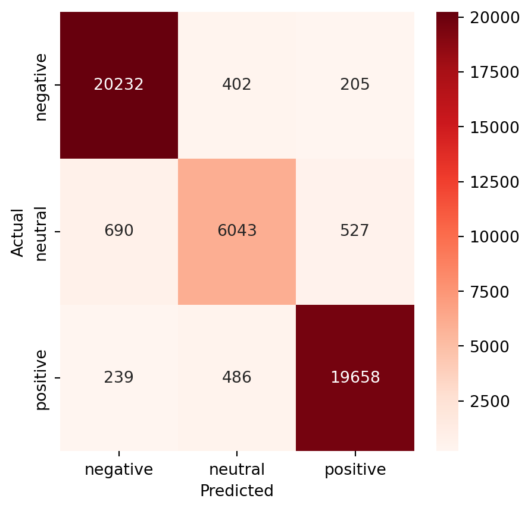

```python
cm=confusion_matrix(y_true, y_pred)

plt.figure(figsize=(5,5))
sns.heatmap(cm, annot = True, xticklabels=label2id.keys(), yticklabels=label2id.keys(), fmt='d',  cmap='Reds')
plt.ylabel("Actual")
plt.xlabel("Predicted")

#cbar=False,
```

Terms for confusion matrix:

We should note that most confusion matrices have just a positive and negative class. Our model has three classes with neutral being the additional class.

True Positive (TP)

```
The predicted value matches the actual value.
The actual value was positive, and the model predicted a positive value.
```

True Negative (TN)

```
The predicted value matches the actual value
The actual value was negative, and the model predicted a negative value.
```

True Neutral (TL)

```
The predicted value matches the actual value
The actual value was neutral, and the model predicted a neutral value.
```

False Positive (FP)

```
The predicted value was falsely predicted.
The actual value was negative or neutral, but the model predicted a  positive value.
```

False Negative (FN)

```
The predicted value was falsely predicted.
The actual value was neutral or positive, but the model predicted a negative value.
```

False Neutral (FL)

```
The predicted value was falsely predicted.
The actual value was negative or positive, but the model predicted a neutral value.
```

We can put these numbers in perspective by using percentages for total predictions for each class.

Of the total predictions for the negative class, 97% were correctly predicted as the negative class, 2% were incorrectly predicted as the neutral class and 1% were incorrectly predicted as the positive class.

Of the total predictions for the neutral class, 83% were correctly predicted as the neutral class, 10% were incorrectly predicted as the negative class, and 7% were incorrectly predicted as the positive class.

Of the total predictions for the positive class, 96.4% were correctly predicted as the positive class, 1.2% were incorrectly predicted as the negative class, and 2.4% were incorrectly predicted as the neutral class.

# Predicting on unlabeled data

Now that we have our pre-trained model fine tuned we will use it to predict on a new dataset. The data includes New York Times comments from the 2018 year.

The fine-tuned model will be saved which allows us to use it for predicting on future data.

```python
model.save_pretrained("./results/final_model")
tokenizer.save_pretrained("./results/final_tokenizer")
```

```python
new_model = AutoModelForSequenceClassification.from_pretrained("./results/final_model")

new_tokenizer = AutoTokenizer.from_pretrained("./results/final_tokenizer")
```

```python
nyt_sentiments18.info()
```

```
<class 'pandas.core.frame.DataFrame'>
RangeIndex: 930320 entries, 0 to 930319
Data columns (total 5 columns):
 #   Column          Non-Null Count   Dtype
---  ------          --------------   -----
 0   commentBody     930319 non-null  object
 1   commentID       930320 non-null  int64
 2   commentType     930320 non-null  object
 3   newDesk         930320 non-null  object
 4   typeOfMaterial  930320 non-null  object
dtypes: int64(1), object(4)
memory usage: 35.5+ MB
```

```python
device=torch.device('cuda' if torch.cuda.is_available() else 'cpu')
```

We are setting the sci_mode (scientific notation) to false for easier interpretation of probability output.

```python
torch.set_printoptions(sci_mode=False)
```

```python
def get_prediction(text):

    """
        Applies fine-tuned model and tokenizer to predict sentiment

        Args:
            text: A string of text.

        Returns:
            probabilites: predicted probability of each sentiment. Probabilites sum to 1.
            id2label[pred]: predicted sentiment label.
    """

    input_encoded = new_tokenizer(text, return_tensors='pt').to(device)

    with torch.no_grad():
        outputs = new_model(**input_encoded)

    logits = outputs.logits
    probabilities = torch.nn.functional.softmax(logits, dim=-1)

    pred = torch.argmax(probabilities, dim=-1).item()
    return probabilities, id2label[pred]
```

We created a function that will take in a string of text and return the probabilities of the predicted sentiments and the predicted sentiment label with the highest probability. Probabilty is the confidence we have in predicted label.

The output for our comment predictions will include the text predicted on, the “Type of Material” category, “News Desk” category, sentiment predicted probabilities, and the predicted label.

```python
print("Comment:",nyt_sentiments18.iloc[50,0])
print("Type of Material:",nyt_sentiments18.iloc[50,4])
print("News Desk:",nyt_sentiments18.iloc[50,3])
print(get_prediction(nyt_sentiments18.iloc[50,0]))
```

```
Comment: Naturally Trump blames Democrats, even after acknowledging his nominee is in serious trouble. Do we wonder why the country is so polarized? Mr. "Witch Hunt" strikes again.
Type of Material: News
News Desk: Washington
(tensor([[0.9998, 0.0002, 0.0001]], device='cuda:0'), 'negative')
```

```python
print("Comment:",nyt_sentiments18.iloc[100,0])
print("Type of Material:",nyt_sentiments18.iloc[100,4])
print("News Desk:",nyt_sentiments18.iloc[100,3])
get_prediction(nyt_sentiments18.iloc[100,0])
```

```
Comment: Isn’t it possible that Jackson jumped at the VA nomination because he realized that the Navy had decided to park him in a dead end job?
Type of Material: News
News Desk: Washington
```

```
(tensor([[0.9997, 0.0003, 0.0001]], device='cuda:0'), 'negative')
```

```python
print("Comment:",nyt_sentiments18.iloc[240,0])
print("Type of Material:",nyt_sentiments18.iloc[240,4])
print("News Desk:",nyt_sentiments18.iloc[240,3])
get_prediction(nyt_sentiments18.iloc[240,0])
```

```
Comment:   What? Really?   Out of the millions of women and men in our government this is our best choice?   I want someone whose goal is to advocate for and serve our veterans first.  The services that our veterans need are often outside the scope and experience of most hospitals and medical practi…
Type of Material: News
News Desk: Washington
```

```
(tensor([[0.0282, 0.9657, 0.0061]], device='cuda:0'), 'neutral')
```

The prediction for this comment is neutral.

```python
print("Comment:",nyt_sentiments18.iloc[310,0])
print("Type of Material:",nyt_sentiments18.iloc[310,4])
print("News Desk:",nyt_sentiments18.iloc[310,3])
get_prediction(nyt_sentiments18.iloc[310,0])
```

```
Comment: Really this is brought on by Trump - nominating &amp; putting in position for serious review someone who has probably done well by our country in his job - but is completely unqualified &amp; obviously has issues with his performance upon more serious scrutiny.  <br/><br/>The conservative m…
Type of Material: News
News Desk: Washington
```

```
(tensor([[0.9994, 0.0004, 0.0001]], device='cuda:0'), 'negative')
```

```python
print("Comment:",nyt_sentiments18.iloc[410,0])
print("Type of Material:",nyt_sentiments18.iloc[100,4])
print("News Desk:",nyt_sentiments18.iloc[410,3])
get_prediction(nyt_sentiments18.iloc[421,0])
```

```
Comment: Why weren't these issues brought up when he was Obama's doctor?  This is an ongoing example that the Democrats show towards any Trump nominee.
Type of Material: News
News Desk: Washington
```

```
(tensor([[0.9996, 0.0003, 0.0001]], device='cuda:0'), 'negative')
```

```python
print("Comment:",nyt_sentiments18.iloc[510,0])
print("Type of Material:",nyt_sentiments18.iloc[510,4])
print("News Desk:",nyt_sentiments18.iloc[510,3])
get_prediction(nyt_sentiments18.iloc[510,0])
```

```
Comment: Kathryn, you are a marksman--markswoman--marksperson.
Type of Material: News
News Desk: Washington
```

```
(tensor([[0.0008, 0.9987, 0.0005]], device='cuda:0'), 'neutral')
```

```python
print("Comment:",nyt_sentiments18.iloc[540,0])
print("Type of Material:",nyt_sentiments18.iloc[540,4])
print("News Desk:",nyt_sentiments18.iloc[540,3])
get_prediction(nyt_sentiments18.iloc[540,0])
```

```
Comment: That was my question, Sooo, how much drinking IS appropriate on the job?
Type of Material: News
News Desk: Washington
```

```
(tensor([[0.0001, 0.0001, 0.9998]], device='cuda:0'), 'positive')
```

```python
print("Comment:",nyt_sentiments18.iloc[588,0])
print("Type of Material:",nyt_sentiments18.iloc[588,4])
print("News Desk:",nyt_sentiments18.iloc[588,3])
get_prediction(nyt_sentiments18.iloc[588,0])
```

```
Comment: Ha! That's really funny!
Type of Material: News
News Desk: Washington
```

```
(tensor([[0.0000, 0.0001, 0.9999]], device='cuda:0'), 'positive')
```

[output not shown]

```
(tensor([[0.0000, 0.0001, 0.9999]], device='cuda:0'), 'positive')
```

```
Comment: I think you have your Kepler fact wrong. Kepler was the assistant not the other way around.
Type of Material: News
News Desk: Games
```

```
(tensor([[0.9993, 0.0005, 0.0001]], device='cuda:0'), 'negative')
```

```
Comment: Surely neither Iran nor Israel will benefit from an all-out war, adding more fuel to the ongoing conflict in Syria.<br/>Tom Friedman blames the “ego-power play” by Iran’s Quds Force leader Qasem Suleimani for tensions with Israel. The commander wants “to extend Iran’s grip on key parts of t…
Type of Material: Op-Ed
News Desk: OpEd
```

```
(tensor([[0.9997, 0.0002, 0.0001]], device='cuda:0'), 'negative')
```

```
Comment: It is true.  We provide the means for the deranged and disturbed to wreak havoc.<br/>We reap what we sow.
Type of Material: News
News Desk: National
```

```
(tensor([[0.9973, 0.0022, 0.0005]], device='cuda:0'), 'negative')
```

```
Comment: Let those without fault throw the first stone.<br/><br/>... and let real crimes be punished by the justice system (as in Dr. Nassar's case) - not the papers or the public. You can trust us to make up our own minds - but censorship is a slippery slope.
Type of Material: News
News Desk: Culture
```

```
(tensor([[0.9982, 0.0014, 0.0003]], device='cuda:0'), 'negative')
```

```
Comment: I don't do facebook, never have never will.  Just too dangerous with my personal information - going to porn sites is less risky than facebook.
Type of Material: News
News Desk: Business
```

```
(tensor([[0.9996, 0.0003, 0.0001]], device='cuda:0'), 'negative')
```

From a our randomly selected sample of comments we find mostly high confidence in the models predictions.

# Fine-tuned model in production

Our fine-tuned model is now ready for production. There are several paths for production. We can build a stand alone web application for our model with platforms such as Streamlit or Gradio, which will allow users to have an interface for uploading text for sentiment prediction. Alternatively, our model can be used as part of an AI Agent.